# *Record Linkage*

Wagner Tassinari

*wtassinari@gmail.com*

08/02/2023

## O que é o *Linkage*

“… é uma solução para o problema de reconhecer registros em duas tabelas (*banco de dados*) que representam pessoas idênticas, objetos ou eventos (considerados correspondentes).”

*Fellegi IP & Sunter AB (1969) A theory for record linkage.Journal of the American Statistical Association 64, 1183-1210.*

## O que é o *Linkage*

- Determinar se pares de registros de dados descrevem a mesma entidade (geralmente pessoas, organizações, etc.), através de atributos desses registros, ex: CPF, CNS, Nome, Endereço, Data de Nascimento, etc.
- No âmbito dos Sistemas de Informação em Saúde (SIS), a técnica de *linkage* permite a recuperação de registros incompletos ou inconsistentes e, com isso, melhora a completitude e a confiabilidade das informações disponibilizadas pelos SIS.

## Tipos de *Linkage*

- **Manual**
  - Não é viável à medida que o número de registros aumenta
- **Determinística**
  - Comparações automáticas onde tudo precisa corresponder ou regras específicas de dados são programadas.
  - Precisa de uma nova regra para cada variação nos dados
  - Não generalizável para outros conjuntos de dados
- **Probabilística**
  - Estimar a probabilidade de duas entidades serem iguais
  - Lida com dados ausentes e variações na codificação

## Etapas para o *Linkage*

- Limpeza de dados
- Padronização dos dados
- Remoção de duplicatas
- Identificação de uma chave primária (*primary key*)
- Deduplicação
- Identificação das variáveis *chaves* para o o *linkage*

## Fluxo do Linkage Probabilístico

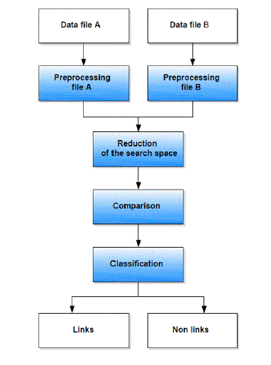

## Fluxo do Linkage Probabilístico

- **Pré-processamento:** desenvolvimento de chaves de relacionamento, ex: concatenação de atributos (ex: nome + nome da mãe + data do nascimento) de forma direta ou via criptografia (ex: HASH MD5)
- **Redução do espaço de busca**: Comparação via estratégias de blocagem, ex: primeiro nome, ultimo nome, ano de nascimento, nome do bairro, etc.
- **Classificação:** Comparação dos atributos via medidas de similaridade
- **Preditor final:** pontos de corte dos scores e validação

https://rpubs.com/ahmademad/RecordLinkage

## Preparação dos bancos de dados

- É importante que, antes de iniciar o processo de vinculação de dados, sejam definidas asvariáveis a serem utilizadas para a análise dos dados vinculados.
- Após a limpeza e padronização dessas informações, é possível explorar o banco de dados para verif icação de registros duplicados.

## Conclusions

[figure not shown]